# Lecture 2

# Lecture 2: Describing genetic diversity

## Genetic diversity writ large

Last week you learned how different evolutionary forces affect allele frequencies at a single site.

This week, we’ll be discussing how we can measure genetic diversity and what those measurements can tell us.

We will look at a few statistics that measure genetic diversity, notably the SFS, $\pi$, $\theta_W$ and $H$.

Before that, we’ll talk about why we even care.

## What is diversity good for?

*Evolution is the change in traits of populations over generations*

Change is impossible if variation does not exist.

Genetic variation allows for evolvability - without it populations are stuck.

*Most* variation might in fact be deleterious in any particular environment.

Conversely, if the environment changes - old variants are unlikely to meet all of its needs.

## Where does diversity come from?

Ultimately, all genetic diversity begins with mutation.

A key quantity in population genetics is $\theta$ - the neutral genetic diversity.

Under Wright-Fisher: no new mutations being introduced. What is the long term expectation?

Let’s first think about *how* to measure diversity.

## Measuring diversity at a site

Before we think about what’s happening across the genome, we can start by asking what is happening at an individual locus.

**Recall**

We will refer to the allele frequency of the *alternate* allele at site $j$ as $p$.

What are some ways we can ask how diverse a population is at a site?

## Expected Heterozygosity ( *H* )

One of the simplest metrics is to ask how frequently we see individuals who are heterozygous.

Let’s start by generalizing to any number of alleles.

$$H_j = 1 - \sum_{i=1}^{k}{p_i^2}$$

Where $p_i$ is the frequency of the $i^{th}$ allele and there are a total of $k$ alleles.

If there are only two alleles:

$$1-p_a^2 -p_A^2 = 2p_a(1-p_a)$$

In practice - often not the case: why?

## Sample heterozygosity (*h*)

Another way to think about genetic diversity is to ask:

What is the probability that if you sample any two alleles in the population, they are different.

But populations are not infinite, and we also don’t sample all possible individuals.

Instead, we calculate the expected *sample* heterozygosity, and account for number of alleles sampled ($n$):

$$h_j=\frac{n}{n-1}\left(1-\sum_i^k{p_i^2}\right)$$

## Heterozygosity and drift

We saw last week how drift alone leads to evolutionary change by fixation and loss of alleles due to random chance.

This can lead to a change in heterozygosity that is quite predictable.

Any generation, the given (true) heterozygosity is $H_t$. What will it be in the next generation?

We can make our lives easier by looking at the inverse $\mathscr{H}$ : the Homozygosity of the population.

Useful to know: $H = 1-\mathscr{H}$.

## How does drift change homozygosity?

Two ways for random pair of alleles to be identical:

[figure not shown]

So: $\mathscr{H}_{t+1} = \frac{1}{2N} + (1-\frac{1}{2N})\mathscr{H_t}$

## Putting it together

Then:

$$H_{t+1} = 1-\frac{1}{2N}-\left(1-\frac{1}{2N}\right)\left(1-H_t\right)=\left(1-\frac{1}{2N}\right)H_t$$

In other words - drift causes heterozygosity to predictably decrease every generation (at a rate of $-\frac{H}{2N}$)

## Let’s check simulations

We can take a look at our simulations:

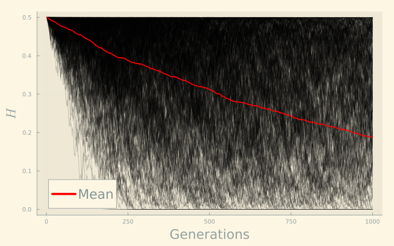

## Versus expectation:

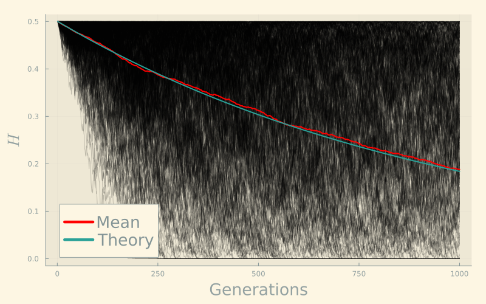

## How quickly does heterozygosity decay?

Will heterozygosity decrease faster in big or small populations? Why?

## Heterozygosity across a region

We can then zoom out and ask what the diversity is across a whole region. Say there are $L$ sites in your region, then the total *polymorphism* is given by:

$$\pi = \sum_{j=1}^{L}{h_j}$$

The more common definition you’ll see is the *per site* *polymorphism/heterozygosity*, given as:

$$\pi = \frac{1}{L}\sum_{j=1}^{L}{h_j}$$

Note, often the two will be labeled as $\pi$, but per-site is far more common.

## Let’s check some intuition

Here, we’ll use the example data from Hahn’s textbook :

```
4-element Vector{String}:
 "TTACAATCCGATCGT"
 "--ACGATGCGCTCGT"
 "TCACAATGCGATGGA"
 "TTACGATG--CTCGT"
```

Each row is an individual, each column is a site. Notice how some sites have missing data “-”.

What is the heterozygosity at the third site?

How can we account for missing data in calculating heterozygosity?

## Code examples

Hahn’s alignment:

[output not shown]

```julia
#| echo: true
using StatsBase

function sample_h(alleles)
    obs_alleles=collect(skipmissing(alleles)) #Genotypes might be missing - we skip those.
    n=length(obs_alleles)
    freqs = values(countmap(obs_alleles)) ./ n #Get allele frequencies for each allele
    return( n/(n-1)*(1-sum(freqs .^ 2))) #Return the expected sample h
end

function sample_π(genotype_matrix)
    return(sum([sample_h(genotype_matrix[:,x]) for x in 1:size(genotype_matrix)[2]])/size(genotype_matrix)[2]) #Sum of h over all sites/number of sites
end

sample_π(replace(hahn_data,"-"=>missing))
```

## What should $\pi$ look like?

We can use some baseline Wright-Fisher model with mutation assumptions to figure out what $\pi$ will be like in practice.

Let’s say there are $N$ individuals. The mutation rate is $\mu$. What is the expected heterozygosity?

## Finding steady-states

One way to solve modeling problems is to enumerate all of the forces acting on them, and find when the forces cancel each other out.

Heterozygosity can increase because of mutation.

Heterozygosity is lost because of drift (recall drift eventually causes alleles to be fixed/lost).

How strong are these forces?

## More formally

Let $\Delta H$ be the change in heterozygosity from one generation to the next.

Then:

$$\Delta H = \Delta mutation + \Delta drift$$

Any individuals *not* heterozygous can become so via mutation at either of their two copies of the locus.

$$\Delta mutation = (1-H)2\mu$$

And drift cause the loss of heterozygosity at the rate we derived earlier:

$\Delta drift = -\frac{H}{2N}$

Then, at steady state:

$$0=(1-H)2\mu-\frac{H}{2N}$$

Chalkboard time!

## Expected heterozygosity

The neutral expected heterozygosity is $4N\mu$. This is often called $\theta$.

Of course, the quantity is different for haploids: $\theta = 2N\mu$

Deviations from $\theta$ are expected to occur because of non Wright-Fisher dynamics.

But do populations actually show this much variation?

## Some examples

[output not shown]

## *Effective* population size ($N_E$)

We often refer not to the census population size, but the effective population size.

The idea is simple - not all individuals in a population actually mate and contribute to the next generation.

These individuals, from the perspective of evolutionary biology, might as well be dead/non-existant.

The *effective population size* is the size of a hypothetical population that evolves under WF dynamics.

## Implication of $N_E$

$N_E$ implies that many individuals in a population don’t actually contribute to the species’ evolution.

Some of this might be due to selection - individuals who simply die/don’t mate.

The quantity $\frac{N_E}{N}$ should tell you what fraction of individuals are surviving/contributing.

More thoughts about this for Thursday’s reading.

## Not the only heterozygosity

$\pi$ is a commonly used estimator for genetic diversity, but it has some issues. The biggest is that when true diversity is high, variance in *sample* diversity is also really high. That is, it’s hard to get an accurate estimate.

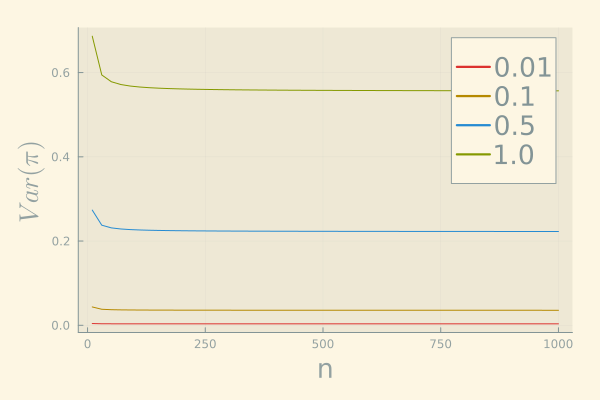

## Alternatives to $\pi$ : $\theta_W$

One common alternative is to use Watterson’s Theta. The idea is that we can simply look at the *number* of segregating sites $S$ (sites with at least one variant). Because as we sample more individuals, we are more likely to sample a new allele, there is a correction factor:

```julia
#| echo: true
function wat_theta(gm)
    S = sum([is_segregating(i) for i in eachcol(gm)])
    a = sum([1/i for i in 1:size(gm)[1]])
    return(S/a)
end
```

## $\theta_W$ - lower variance with greater sampling

Unlike $\pi$, $\theta_W$ shows a nice decrease in sample variance with more samples.

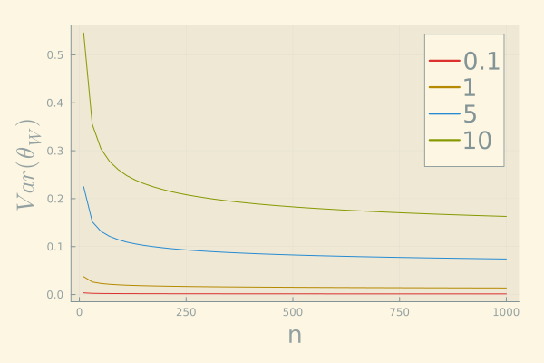

## Why is $\theta_W$ not the standard?

Accuracy from sample size is not the only potential issue:

$\theta_W$ is not robust to other sources of errors:

- missing data
- sequencing error
- uneven sampling

In practice, it’s often good to be able to look at multiple different estimators, and make informed conclusions about the data from them.

## Tajima’s D

In fact, we’ll later cover how expected differences between $\pi$ and $\theta_W$ can be used to examine population demographic history.

For now - let’s keep thinking about how to summarize genetic variation in a population.

## Single data point for whole genome?

$\theta$, $\pi$, $h$ and similar are *summary statistics* - they reduce potentially huge amounts of data into a single number. That *can* be useful, but sometimes it’s better to look at a denser view of the data. Let’s make a larger/more complicated data-set.

```
100-element Vector{String}:
 "CGCCACTACGTGTCGAAACGTCATGTGCAC" ⋯ 9940 bytes ⋯ "CTCCCAGTCTTATGAATATGCACGGTGTAC"
 "CGCCGCTCCTGCACCAAACGTCATGTTCAC" ⋯ 9940 bytes ⋯ "CTCCCAGTCGTATGAATGTGCACGGTGTGC"
 "CCCTACTACGTCTCCAAACGTCATGTGTAC" ⋯ 9940 bytes ⋯ "TTCCCAGTCTTATGAAGGTGCACGGTGCAC"
 "CCCCATGACGTCTCGAAACGTCATGTGCAC" ⋯ 9940 bytes ⋯ "CTCCCAGCCTTATGTA-GTGCATGGGGTGC"
 "CCCCACTACTTGTCCAAGCGTCA-GTTTAC" ⋯ 9940 bytes ⋯ "CTCACAGTCTTATGTATGTACACGGTGTAC"
 "CGCCATTACTTGTCCAAGCGTCATATGTAC" ⋯ 9940 bytes ⋯ "CTCACAGTCGTATGAAGGTGGATGGTGTGC"
 "CCCCACTACGTCTCGAAACGTCATGTTCAC" ⋯ 9940 bytes ⋯ "CTCACAGTCGTATGAATGTACACGGTGTAC"
 "CGCTGCTACTGCTCCAAAGGTCCTGTGCAC" ⋯ 9940 bytes ⋯ "CTCCCAGTCTTATGAATGTACACGGGGTAC"
 "CCCCATTCTTTCTAGAAACGGCATATGTAC" ⋯ 9940 bytes ⋯ "CTCCAAGCCTTATGAAGGGGCATGGTGTAC"
 "CCCCACTCTTGC-AGAAGCGTCATGTGCAC" ⋯ 9940 bytes ⋯ "CTCCAAGCCTTATGAAGATGCACGGTGTAC"
 ⋮
 "CCCGACTTCGTAGAGAAGCGGCATGTGTAC" ⋯ 9940 bytes ⋯ "GGCAGATTATTGAGATGTTAAAC-GTGGAC"
 "CCCGACTTCGTGGCTAAACGTCATGTGTAC" ⋯ 9940 bytes ⋯ "CGCAGATTCTTAAGATGGTGCCCGGTGGAA"
 "CGCGTCTCCGTGGCTAAACGGCATGTGTAC" ⋯ 9940 bytes ⋯ "CGCACATTATTAAGAAGGTACACGGTGGAC"
 "CCCGACTCCA-GGCTAAACGTCATATGTAC" ⋯ 9940 bytes ⋯ "-TCAGATTATTAAGCAGGAACACGGTGTAA"
 "CCCGACTCCATGGATAAACGTCATGTGTAC" ⋯ 9940 bytes ⋯ "CTCAGATTACTATGAAGTTGAATGGTGGAC"
 "CGCGACTCCGTGGCTAAACGGCATGTGTAC" ⋯ 9940 bytes ⋯ "CTCAGATTCTTAAGCTTTTAAATGGAGGAC"
 "CCCGACTCGGTAGCTAAACGTCATGTGTGC" ⋯ 9940 bytes ⋯ "GTCAGATTCTTATGATGGTGAATGGTCGAA"
 "CCCGACTTGATGGCTAAACGTCATATGTAC" ⋯ 9940 bytes ⋯ "CGCACATTCTTAAGCATGTAACTGGAGGAA"
 "CGCGACTCGGTAGCTAGACGTCATGTGTAC" ⋯ 9940 bytes ⋯ "GTCAGATTATTATAAAGTAAACCGGAGGAC"
```

## Windowed statistics

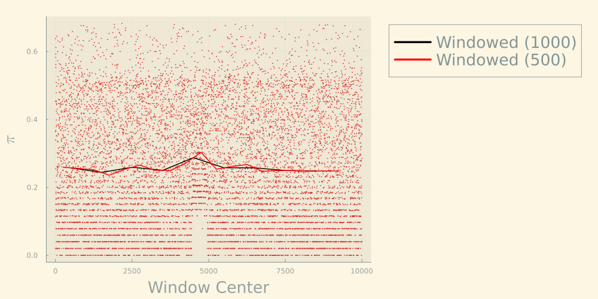

## But window choice not arbitrary

As we’ll discuss in the next lecture: our choice of windows might depend on factors like recombination rate.

Frequently, studies use a *single* window value. But different parts of the genome have different degrees of LD, mutation, recombination.

In general - good idea to run a sliding window analysis.

## Sliding windows

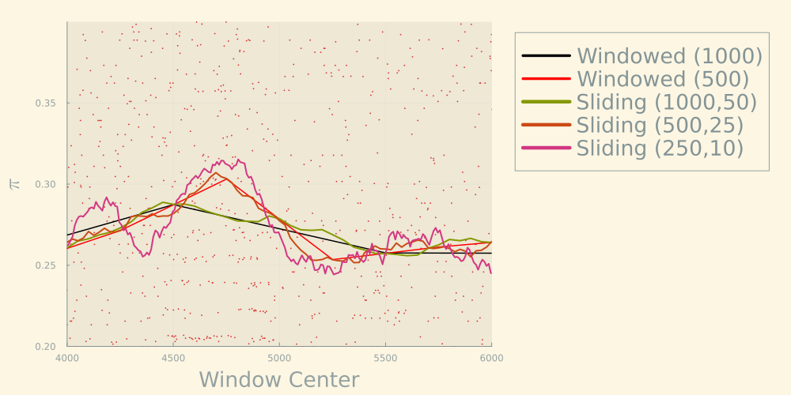

## Longer alignment - more information

One good way to represent a whole region is to summarize the allele frequencies at each site. This is called the *Site Frequency Spectrum*, or (*Allele Frequency Spectrum*). In our complicated alignment, it helps us see the frequency of different alleles.

## SFS example:

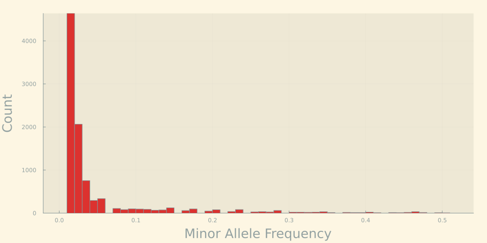

## Allele *polarity*: ancestral state

When you don’t know what the ancestral allele is, you generally examine the *minor* allele frequency (whichever is rarer.

This results in a *folded* SFS.

But, if you have an outgroup/ancestral data, you can instead use the full SFS.

## Unfolded SFS

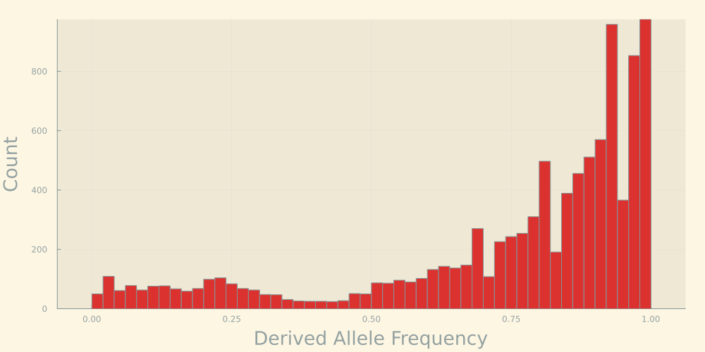

## What do you do with the SFS

One of the uses of the SFS is, ironically, to calculate summary statistics.

Some, like $\theta_H$ estimate the genetic diversity.

Others, like Tajima’s D let you estimate the influence of demography on the population.

Once we talk about demography estimation - SFS contains most data needed.

## How is variation distributed among individuals?

We can now say something about how genetic variation is sumarised across a population. *But* this gives us very little information about how the variation is distributed within each individual.

For instance, if overall $\pi$ is high - does that mean that every individual is likely to *be* heterozygous?

## Summarizing complex data: PCA

Principal component analysis (PCA) is an approach to take complex, highly dimensional data (like the genotypes of a bunch of individuals at very many sites), and reduce it to something simpler.

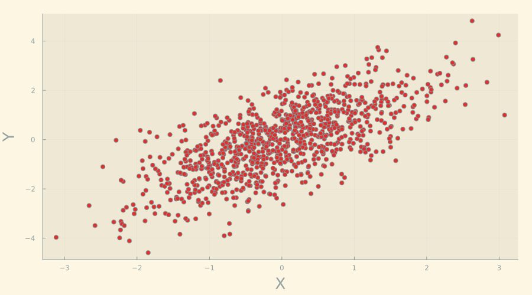

## PC1 identifies the axis of highest variability

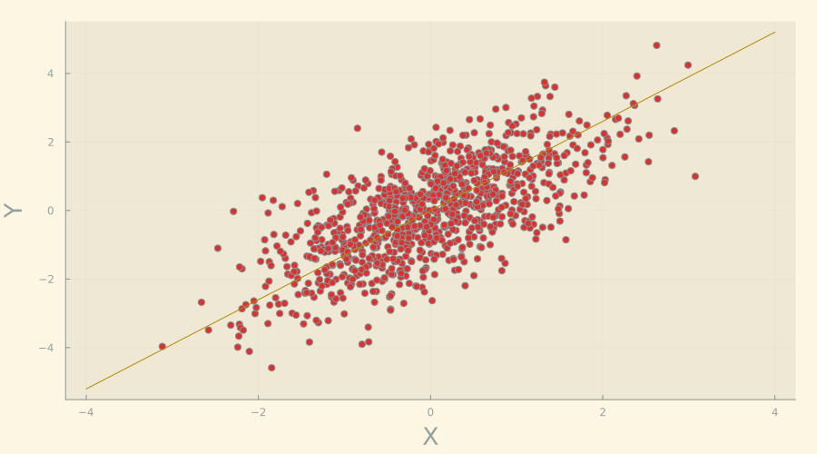

## Each PC explains the next most variation

When data fits PCA assumptions, each subsequent PC explains the next most variance.

Technical details: the first principal component is the eigenvector of the correspondingly largest eigenvalue of a covariance matrix between data points.

i.e.: You correlate all data points, and ask what linear transformations explain the covariation. This in turn explains the most variation in the data.

## Works in genomic data too!

Here’s our toy sequence data along the first two PCs.

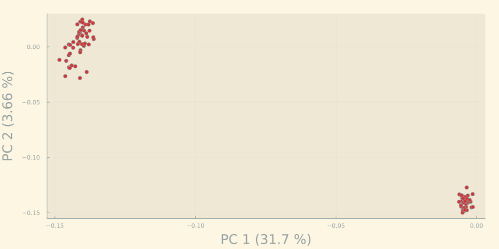

## Is PCA always worth it?

How do you know how many PCs are “enough” to describe your data?

PCA significance can be evaluated using the *broken stick model*.

If you choose *n* random break points of a stick of length 1, then the size of these segments follows a typical distribution:

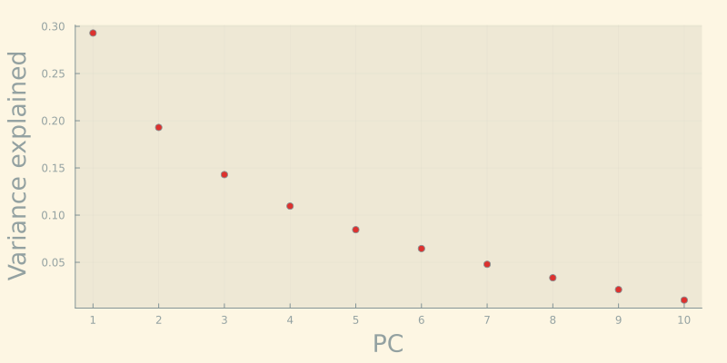

## How does that compare to our toy sequence data?

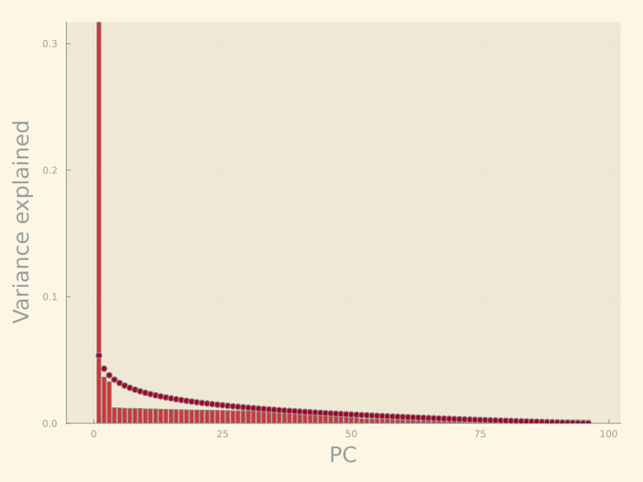

## PCA can be deceiving!

Unequal sampling can make it seem like one subgroup has all the “important” variation, but they are just sampled better.

Samples from different time points can create illusion of similarity between populations/individuals.

Interesting variation is not necessarily along the first PC axis.

In this case: 500 bp bit of basically random sequence in 10 individuals in pop2.

## Other ways of thinking about genetic variation

We’ve considered how much variability there is at a locus/across the genome.

We’ve considered how that variation might be partitioned among all the samples.

Let’s ask how variation might be partitioned within a population.

## $F$-statistics (inbreeding coefficients)

We’ve talked a lot about *expected* heterozygosity, but actual observed heterozygosity is also informative.

Let $F$ be the coefficient of inbreeding (the probability that any two alleles are identical by descent).

Then:

$$\begin{cases}
p_{AA} = p^2(1-F)+pF \\
p_{Aa} = 2pq(1-F) \\
p_{aa} = q^2(1-F)+qF \\
\end{cases}$$

In other words - the frequency of heterozygotes is decreased, while homozygotes increase.

What should $F$ be in Wright-Fisher?

## $F_{IS}$ - Inbreeding statistic

To actually study inbreeding it’s more useful to examine this across the whole genome rather than a single locus.

## Case study

Let’s look at a case study of some allele data:

[output not shown]

Should get: 0.28, 0.34, -0.4

## Are any of these *significant* deviations?

Simple to test if population is statistically deviating from HW ($\chi^2$ tests, for instance).

Rule of thumb - differences w/in 5% of expectation (e.g. $F_{IS} ~0.05$) happen in neutral simulations all of the time.

Bigger differences - actually perform testing.

## Inbred population, or inbred individuals?

One way to look for individuals who may be inbred is to look for *Runs of Homozygosity* (ROH)

We’ll talk more when we cover LD and recombination, but not only should inbred individuals have more homozygous alleles than expected, these alleles should also be clustered.